# Tidy Tuesday #37: NYC Restaurant Inspections

Jerrick Tram

2018-12-10

# Backstory

New York is known for its cuisine from the greasiest of pizzas to the finest of eateries. However, restaurants still have a standard to uphold to function in society. Based on a [538 article](https://fivethirtyeight.com/features/how-data-made-me-a-believer-in-new-york-citys-restaurant-grades/), NYC restaurants from 2010 to 2014 have shown improvements in terms of health grade. But, we would like to see what type of restaurants typically achieve that high rating. Do restaurants that serve Asian cuisine have a higher probability of receiving an A vs a restaurant that serves American cuisine? What restaurants are at risk of receiving a violation?

```r
library(tidyverse)  # For data wrangling and visualization
library(janitor)    # For data cleaning

set.seed(12345)     # For reproducibility

df <- read_csv("https://data.cityofnewyork.us/api/views/43nn-pn8j/rows.csv")

# Because we only care about the restaurants and their health grade
# we can throw out irrelevant data

sampled_df <- df %>%
  janitor::clean_names() %>%
  select(-phone,
         -grade_date,
         -record_date,
         -building,
         -street,
         -zipcode,
         -inspection_date) %>%
  sample_n(size = 300000)

# Save as csv
write_csv(sampled_df, "nyc_restaurants.csv")
```

# Data Wrangling

```r
sampled_df %>%
  group_by(as.factor(cuisine_description)) %>%
  summarize(total = n())
```

| as.factor(cuisine_description) | total |
| --- | --- |
| Afghan | 130 |
| African | 1205 |
| American | 65059 |
| Armenian | 300 |
| Asian | 4962 |
| Australian | 245 |
| Bagels/Pretzels | 2248 |
| Bakery | 9264 |
| Bangladeshi | 781 |
| Barbecue | 548 |

[output cut: 75 more lines]

Looking at the type of restaurants, there’s quite a bit that overlap so we’d be better off lumping restaurants that share similiar traits. For example, Hotdogs or Bagel cuisine could be collapsed into Carnival cuisine.

```r
sampled_df <- sampled_df %>%
  mutate(cuisine_description = fct_collapse(cuisine_description,
    Southern = c("Cajun", "Creole", "Creole/Cajun", "Southwestern"),
    Tavern = c("American",
               "Barbecue",
               "Bottled beverages, including water, sodas, juices, etc.",
               "Californian",
               "Chicken",
               "Hamburgers",
               "Pizza",
               "Sandwiches",
               "Soul Food",
               "Soups",
               "Soups & Sandwiches",
               "Steak"),
    Carnival = c("Bagels/Pretzels",
                 "Hotdogs",
                 "Hotdogs/Pretzels",
                 "Ice Cream, Gelato, Yogurt, Ices",
                 "Juice, Smoothies, Fruit Salads",
                 "Nuts/Confectionary"),
    Continental = c("CafÃ©/Coffee/Tea",
                    "Continental",
                    "Delicatessen",
                    "Donuts",
                    "Fruits/Vegetables",
                    "Pancakes/Waffles",
                    "Salads",
                    "Sandwiches/Salads/Mixed Buffet",
                    "Vegetarian"),
    Eastern_Asia = c("Chinese",
                     "Chinese/Cuban",
                     "Chinese/Japanese",
                     "Japanese",
                     "Korean",
                     "Asian"),
    Eastern_European = c("Armenian", "Czech", "Eastern European", "Russian"),
    Mediterranean = c("Greek",
                      "Mediterranean",
                      "Moroccan",
                      "Italian",
                      "Pizza/Italian"),
    Middle_East = c("Egyptian", "Iranian", "Middle Eastern", "Turkish"),
    Other = c("Not Listed/Not Applicable", "Other"),
    African = c("African", "Ethiopian"),
    Latin = c("Latin (Cuban, Dominican, Puerto Rican, South & Central American)",
              "Mexican",
              "Tex-Mex"),
    Polynesian = c("Polynesian", "Hawaiian",  "Seafood", "Indonesian", "Filipino"),
    South_American = c("Brazilian", "Chilean", "Peruvian"),
    South_Asia = c("Afghan", "Bangladeshi", "Indian", "Pakistani"),
    Southeastern_Asia = c("Thai", "Vietnamese/Cambodian/Malaysia"),
    Spanish = c("Basque", "Spanish", "Tapas"),
    UK = c("English", "Irish"),
    Western_Europe = c("German",
                       "French",
                       "Portuguese",
                       "Polish",
                       "Scandinavian")
          )
      )
```

Not the greatest of classifications but it should suffice. Now it’s time to plot.

# Data Visualization

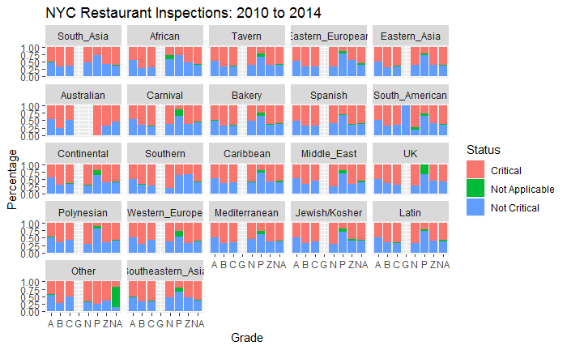

```r
sampled_df %>%
  mutate(grade = fct_collapse(grade, N = "Not Yet Graded")) %>%
  ggplot(aes(grade, fill = critical_flag)) +
  geom_bar(position = "fill") +
  facet_wrap(~ cuisine_description) +
    labs(x = "Grade",
         y = "Percentage",
         title = "NYC Restaurant Inspections: 2010 to 2014",
         fill = "Status")
```

Across the board, restaurants generally improve their status after being revaluated again. Australian cuisine in particular, is interesting as the majority of their restaurants still achieve Critical status despite reevaluation. Southern restaurants that received a grade of a “B” or “C” are at high risk of receiving health violations although serving comfort food doesn’t have much of an entry barrier vs other styles of food. Feel free to look among the different type of cuisine for other surprising observations.